# Homework Assignment 4

Text-Mining

Gus Lipkin - glipkin6737@floridapoly.edu

# DTMT in 2021

- HW4. Text mining HW
- Due day: Nov 12 - Nov 18 at 11:59pm (EST)
- The HW4 is modified by Jikhan Jeong and the original one comes from Prof. Rei.
- If you feel difficult, please go over the previous R practices as follow;
1. CW_intro_tidytext_format-by-jj.html
2. CW_sentiment-analysis-jj.html

ps. you need to modify the original code for this homework.

- Point 100 points
- Reference for data handling in R : https://r4ds.had.co.nz/index.html
- Reference for mudate function : https://r4ds.had.co.nz/transform.html#add-new-variables-with-mutate
- Reference book: https://www.tidytextmining.com/
- Reference Github: https://github.com/dgrtwo/tidy-text-mining

Run the code below to lad the `tidyverse` package for data transformation and visualization, the `dbscan` package for clustering and outlier detection, and the `factoextra` package for quick visualizations of models (you are not required to use `factoextra` and can choose to use other methods for creating visualizations that explain your results when requested)

```r
getwd()
```

```
[1] "/Users/guslipkin/Documents/Fall2021/CAP 4770 ~ Data Mining/CAP 4770 Homework"
```

```r
library(tidyverse)
library(tidytext)
library(gutenbergr)
```

# Problem 1 : Tidytext (20 points)

- ref: CW_intro_tidytext_format-by-jj.html
- dataset: time.machine

```r
time.machine <- gutenberg_download(c(35)); summary(time.machine)
```

```
  gutenberg_id     text
 Min.   :35    Length:3174
 1st Qu.:35    Class :character
 Median :35    Mode  :character
 Mean   :35
 3rd Qu.:35
 Max.   :35
```

```r
head(time.machine)
```

| gutenberg_id | text |
| --- | --- |
| 35 | The Time Machine |
| 35 |  |
| 35 | An Invention |
| 35 |  |
| 35 | by H. G. Wells |
| 35 |  |

```r
dim(time.machine)
```

```
[1] 3174    2
```

### (To-Do, 10 points) Q1-1

- step 1: tokenization using **unnest_kokens** method
- step 2: remove stop_words using **anti_join** method
- step 3: show the output after step 1 and 2 using **head** method (5 points)
- step 4: what are the top 2 word? (5 points)

```r
time.machine <- time.machine %>%
  unnest_tokens(word, text) %>%
  anti_join(stop_words)
head(time.machine, 10)
```

| gutenberg_id | word |
| --- | --- |
| 35 | time |
| 35 | machine |
| 35 | invention |
| 35 | contents |
| 35 | introduction |
| 35 | ii |
| 35 | machine |
| 35 | iii |
| 35 | time |
| 35 | traveller |

> The top two words are `time` and `machine`

### (To-Do, 10 points) Q1-2

- step 1: show the historgram of top10 words in machine learning using *slice* method and *ggplot* (10 points)
- ref: CW_sentiment-analysis-jj.html

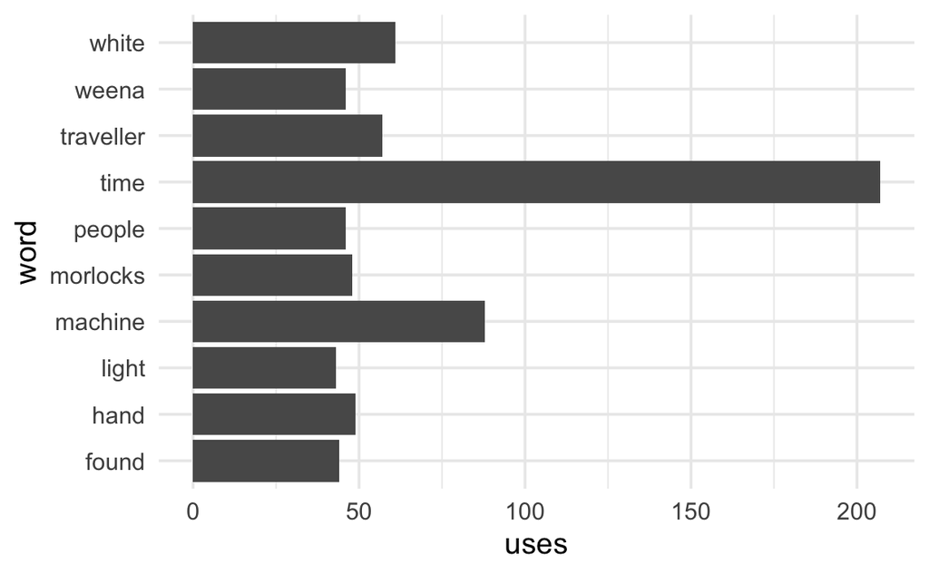

```r
time.machine %>%
  group_by(word) %>%
  summarise(uses = n()) %>%
  arrange(desc(uses)) %>%
  slice(1:10) %>%
  ggplot() +
  geom_bar(aes(x = word, y = uses), stat = "identity") +
  coord_flip() +
  theme_minimal()
```

# Problem 2 : Sentimental Analysis with *bing* lexicon

- dataset : lyrics

```r
lyrics <- read_csv("https://raw.githubusercontent.com/reisanar/datasets/master/BB_top100_2015.csv");lyrics
```

| Rank | Song | Artist | Year | Lyrics | Source |
| --- | --- | --- | --- | --- | --- |
| 1 | uptown funk | mark ronson featuring bruno mars | 2015 | this hit that ice cold michelle pfeiffer that white gold this one for them hood girls them good girls straight masterpieces stylin whilen livin it up in the city got chucks on with saint laurent got k… | 1 |
| 2 | thinking out loud | ed sheeran | 2015 | when your legs dont work like they used to before and i cant sweep you off of your feet will your mouth still remember the taste of my love will your eyes still smile from your cheeksand darling i wil… | 1 |
| 3 | see you again | wiz khalifa featuring charlie puth | 2015 | its been a long day without you my friend and ill tell you all about it when i see you again weve come a long way from where we began oh ill tell you all about it when i see you again when i see you a… | 1 |
| 4 | trap queen | fetty wap | 2015 | im like hey wassup hello seen yo pretty ass soon as you came in the door i just wanna chill got a sack for us to roll married to the money introduced her to my stove showed her how to whip it now she … | 1 |
| 5 | sugar | maroon 5 | 2015 | im hurting baby im broken down i need your loving loving i need it now when im without you im something weak you got me begging begging im on my kneesi dont wanna be needing your love i just wanna be … | 1 |
| 6 | shut up and dance | walk the moon | 2015 | oh dont you dare look back just keep your eyes on me i said youre holding back she said shut up and dance with me this woman is my destiny she said oh oh oh shut up and dance with mewe were victims of… | 1 |
| 7 | blank space | taylor swift | 2015 | nice to meet you where you been i could show you incredible things magic madness heaven sin saw you there and i thought oh my god look at that face you look like my next mistake loves a game want to p… | 1 |
| 8 | watch me | silento | 2015 | now watch me whip kill it now watch me nae nae okay now watch me whip whip watch me nae nae want me do itnow watch me whip kill it watch me nae nae okay now watch me whip whip watch me nae nae can you… | 1 |
| 9 | earned it | the weeknd | 2015 | you make it look like its magic cause i see nobody nobody but you you you im never confused hey heyim so used to being used so i love when you call unexpected cause i hate when the moments expected so… | 1 |
| 10 | the hills | the weeknd | 2015 | your man on the road he doin promo you said keep our business on the lowlow im just tryna get you out the friend zone cause you look even better than the photos i cant find your house send me the info… | 1 |

[output cut: 90 more lines]

```r
lyrics <- select(lyrics, -Year, -Source); head(lyrics)
```

| Rank | Song | Artist | Lyrics |
| --- | --- | --- | --- |
| 1 | uptown funk | mark ronson featuring bruno mars | this hit that ice cold michelle pfeiffer that white gold this one for them hood girls them good girls straight masterpieces stylin whilen livin it up in the city got chucks on with saint laurent got k… |
| 2 | thinking out loud | ed sheeran | when your legs dont work like they used to before and i cant sweep you off of your feet will your mouth still remember the taste of my love will your eyes still smile from your cheeksand darling i wil… |
| 3 | see you again | wiz khalifa featuring charlie puth | its been a long day without you my friend and ill tell you all about it when i see you again weve come a long way from where we began oh ill tell you all about it when i see you again when i see you a… |
| 4 | trap queen | fetty wap | im like hey wassup hello seen yo pretty ass soon as you came in the door i just wanna chill got a sack for us to roll married to the money introduced her to my stove showed her how to whip it now she … |
| 5 | sugar | maroon 5 | im hurting baby im broken down i need your loving loving i need it now when im without you im something weak you got me begging begging im on my kneesi dont wanna be needing your love i just wanna be … |
| 6 | shut up and dance | walk the moon | oh dont you dare look back just keep your eyes on me i said youre holding back she said shut up and dance with me this woman is my destiny she said oh oh oh shut up and dance with mewe were victims of… |

### (To-Do, 10 points) Q2-1 : pre-processing

- Step 1: select top 5 songs using *filter*
- Step 2: tokenization using *unnest_tokens*
- Step 3: remove stopword and format change for UTF-8 using *str_detect* with *filter*
- Step 4: shows the results in step 3 using *head* (10 points)

```r
top_5 <- lyrics %>%
  filter(Rank %in% 1:5) %>%
  unnest_tokens(word, Lyrics) %>%
  filter(!word %in% stop_words$word,
         str_detect(word, "[a-z]"))

head(top_5,5)
```

| Rank | Song | Artist | word |
| --- | --- | --- | --- |
| 1 | uptown funk | mark ronson featuring bruno mars | hit |
| 1 | uptown funk | mark ronson featuring bruno mars | ice |
| 1 | uptown funk | mark ronson featuring bruno mars | cold |
| 1 | uptown funk | mark ronson featuring bruno mars | michelle |
| 1 | uptown funk | mark ronson featuring bruno mars | pfeiffer |